# STA302 Project Part 2 – 分析（仅训练集）

SOC 2025 新建独栋住宅售价：面积 × Census division

Group [##]

2026-11-02

> **说明**：本文件是组内的 Part 2 工作稿，叙述用中文，代码与图用英文。它读取 `Part1_Code.Rmd` 写出的 `data/cleaned/soc_clean.csv`，所以**先 knit Part 1，再 knit 本文件**。

> **全部分析只用训练集（4,330 行）。** 测试集的行在读入后立即丢弃；最后一节”测试集最终验证”的代码块 设为 `eval = FALSE`，只在 Part 2 全部定稿后运行一次。

```r
library(MASS)       # boxcox()
library(car)        # vif()
library(sandwich)   # vcovHC(), vcovCL()
library(lmtest)     # coeftest()
set.seed(302)
dir.create("figures", showWarnings = FALSE)
```

# 1 数据：只保留训练集

```r
division_levels <- c("SouthAtlantic", "NewEngland", "MidAtlantic", "ENCentral", "WNCentral",
                     "ESCentral", "WSCentral", "Mountain", "Pacific")
factor_levels <- list(
  division = division_levels, stories = c("1", "2", "3plus"),
  bedrooms = c("2orless", "3", "4", "5plus"), fullbath = c("1orless", "2", "3", "4plus"),
  halfbath = c("0", "1", "2plus"), garage = c("1car", "2car", "3plus", "other"),
  foundation = c("basement", "crawl", "slab", "other"), fireplace = c("0", "1", "2plus"),
  hoa = c("no", "yes"), age_restricted = c("no", "yes"),
  wall = c("brick", "wood", "stucco", "vinyl", "stone", "fibercement", "other"),
  heat_fuel = c("electric", "gas", "propane", "other"), sewer = c("public", "septic"),
  stage = c("completed", "under_constr", "not_started"))
prep <- function(d) {
  for (v in names(factor_levels)) {
    if (v %in% names(d)) d[[v]] <- factor(d[[v]], levels = factor_levels[[v]])
  }
  d$log_price <- log(d$price_k)
  d$log_sqft <- log(d$sqft100 * 100)
  d
}

soc_all <- read.csv("data/cleaned/soc_clean.csv", stringsAsFactors = FALSE)
train <- prep(soc_all[soc_all$split == "train", ])
rm(soc_all)                       # test rows are discarded here and never used below
n <- nrow(train)
n
```

```
#> [1] 4330
```

```r
skew <- function(x) { z <- x - mean(x); mean(z^3) / mean(z^2)^1.5 }
exkurt <- function(x) { z <- x - mean(x); mean(z^4) / mean(z^2)^2 - 3 }
bp_koenker <- function(m, e = resid(m), X = model.matrix(m)) {   # Koenker (studentized) BP
  e2 <- e^2; aux <- lm.fit(X, e2)
  r2 <- 1 - sum(aux$residuals^2) / sum((e2 - mean(e2))^2)
  LM <- length(e2) * r2; df <- ncol(X) - 1
  c(LM = LM, df = df, p = pchisq(LM, df, lower.tail = FALSE))
}
r2 <- function(m) summary(m)$r.squared
adjr2 <- function(m) summary(m)$adj.r.squared
# nested F test (classical) and HC3 Wald F test for the terms that differ between two models
pf_test <- function(full, red) {
  a <- anova(red, full)
  c(F = a$F[2], df = a$Df[2], p = a[2, "Pr(>F)"], dR2 = r2(full) - r2(red))
}
# HC3 covariance. Identical to vcovHC(m, type = "HC3") except that an observation with leverage 1
# (its residual is exactly 0 and e/(1-h) is 0/0) contributes 0 to the "meat" instead of NaN.
# This only matters in the division x fullbath confounding check, where one division-by-bathroom
# cell contains a single house.
vcov_hc3 <- function(m) {
  vcovHC(m, omega = function(residuals, diaghat, df)
    ifelse(diaghat > 1 - 1e-10, 0, residuals^2 / (1 - diaghat)^2))
}
fp <- function(p) formatC(p, format = "e", digits = 2)       # p-values for tables
# HC3 Wald F test that the coefficients in `full` but not in `red` are all zero. Written out by hand
# (same as lmtest::waldtest(full, red, vcov = vcovHC(full, "HC3"), test = "F")) because waldtest()
# refuses models with aliased (NA) coefficients, which occur in one confounding check below.
hc3_test <- function(full, red) {
  b <- coef(full); b <- b[!is.na(b)]
  V <- vcov_hc3(full)[names(b), names(b)]
  tt <- setdiff(names(b), names(coef(red))[!is.na(coef(red))])
  q <- length(tt)
  Fs <- drop(t(b[tt]) %*% solve(V[tt, tt]) %*% b[tt]) / q
  c(F = Fs, df = q, p = pf(Fs, q, df.residual(full), lower.tail = FALSE))
}
# slope of the focal variable in each division: beta_X + beta_{X:division_g}
div_slopes <- function(m, x, V = vcov(m), df = df.residual(m)) {
  b <- coef(m)
  t(sapply(division_levels, function(g) {
    L <- setNames(numeric(length(b)), names(b)); L[x] <- 1
    if (g != "SouthAtlantic") L[paste0(x, ":division", g)] <- 1
    est <- sum(L * b); se <- sqrt(drop(t(L) %*% V %*% L)); tq <- qt(0.975, df)
    c(est = est, se = se, lower = est - tq * se, upper = est + tq * se,
      p = 2 * pt(-abs(est / se), df))
  }))
}
icc_oneway <- function(r, g) {                   # one-way ANOVA ICC estimator
  g <- factor(g); k <- nlevels(g); N <- length(r); ni <- as.numeric(table(g))
  gm <- tapply(r, g, mean)
  msb <- sum(ni * (gm - mean(r))^2) / (k - 1)
  msw <- sum((r - gm[as.character(g)])^2) / (N - k)
  n0 <- (N - sum(ni^2) / N) / (k - 1)
  (msb - msw) / (msb + (n0 - 1) * msw)
}
fig_out <- function(name, width, height, draw) {
  png(file.path("figures", name), width = width, height = height, units = "in", res = 200)
  draw(); invisible(dev.off()); draw()
}
pt_col <- adjustcolor("#33658a", alpha.f = 0.25); ln_col <- "#d1495b"
```

# 2 起点：Part 1 模型（原始售价）

```r
ctrl_all <- "lot_k + stories + bedrooms + fullbath + halfbath + garage + foundation + fireplace + hoa + age_restricted + wall + heat_fuel + sewer + stage + sale_month"
f1 <- as.formula(paste("price_k ~ sqft100 * division +", ctrl_all))
m1 <- lm(f1, data = train)
m1_noint <- update(m1, . ~ . - sqft100:division)
m1_noX <- update(m1, . ~ . - sqft100:division - sqft100)
p1_int_F <- pf_test(m1, m1_noint)
p1_int_hc3 <- hc3_test(m1, m1_noint)
rbind(partial_F = p1_int_F[c("F", "df", "p")], HC3_Wald = p1_int_hc3)
```

```
#>                  F df            p
#> partial_F 37.27242  8 1.181457e-57
#> HC3_Wald  16.22407  8 7.516248e-24
```

```r
slopes_p1 <- div_slopes(m1, "sqft100")
slopes_p1_hc3 <- div_slopes(m1, "sqft100", V = vcov_hc3(m1))
knitr::kable(data.frame(round(slopes_p1[, 1:4], 2), se_HC3 = round(slopes_p1_hc3[, "se"], 2),
                        p_HC3 = fp(slopes_p1_hc3[, "p"])),
             caption = "Part 1 模型各 division 的面积斜率（千美元 / 100 sqft）")
```

Part 1 模型各 division 的面积斜率（千美元 / 100 sqft）

|  | est | se | lower | upper | se_HC3 | p_HC3 |
| --- | --- | --- | --- | --- | --- | --- |
| SouthAtlantic | 11.83 | 0.63 | 10.60 | 13.07 | 0.81 | 9.82e-47 |
| NewEngland | 19.26 | 2.15 | 15.05 | 23.47 | 5.49 | 4.52e-04 |
| MidAtlantic | 24.56 | 1.14 | 22.32 | 26.79 | 5.15 | 1.92e-06 |
| ENCentral | 6.85 | 0.85 | 5.19 | 8.51 | 1.00 | 9.69e-12 |
| WNCentral | 10.57 | 1.15 | 8.32 | 12.82 | 1.23 | 1.49e-17 |
| ESCentral | 13.78 | 0.97 | 11.88 | 15.68 | 1.42 | 5.01e-22 |
| WSCentral | 9.27 | 0.79 | 7.71 | 10.82 | 0.87 | 2.08e-26 |
| Mountain | 14.60 | 0.80 | 13.03 | 16.17 | 1.23 | 3.97e-32 |
| Pacific | 21.70 | 1.14 | 19.47 | 23.92 | 1.52 | 2.26e-45 |

Part 1 的主要问题（见 Part 1 残差分析）：右偏重尾（残差偏度 2.04、 超额峰度 18.0）、明显异方差（喇叭形）、残差对面积和拟合值有轻微弯曲。

# 3 Box-Cox 变换

`MASS::boxcox()` 在 Part 1 的完整设计矩阵下计算 λ 的轮廓对数似然。用 0.001 的细网格；另用 `optimize()` 求精确最大值，以便与 Python（先 0.05 粗网格、再 0.005 细网格）比较。

```r
# y = TRUE stores the response so that boxcox() does not need to re-fit the model
bc <- boxcox(lm(f1, data = train, y = TRUE), lambda = seq(-1, 0.5, by = 0.001), plotit = FALSE)
lambda_hat <- bc$x[which.max(bc$y)]
lambda_ci <- range(bc$x[bc$y > max(bc$y) - qchisq(0.95, 1) / 2])
# exact maximiser of the same profile log-likelihood
X1 <- model.matrix(m1); y1 <- train$price_k; qr1 <- qr(X1)
bc_ll <- function(l) {
  yt <- if (abs(l) < 1e-12) log(y1) else (y1^l - 1) / l
  -n / 2 * log(sum(qr.resid(qr1, yt)^2)) + (l - 1) * sum(log(y1))
}
lambda_exact <- optimize(bc_ll, c(-1, 0.5), maximum = TRUE, tol = 1e-10)$maximum
c(lambda_grid = lambda_hat, ci_low = lambda_ci[1], ci_high = lambda_ci[2], lambda_exact = lambda_exact)
```

```
#>  lambda_grid       ci_low      ci_high lambda_exact
#>   -0.4210000   -0.4700000   -0.3720000   -0.4208349
```

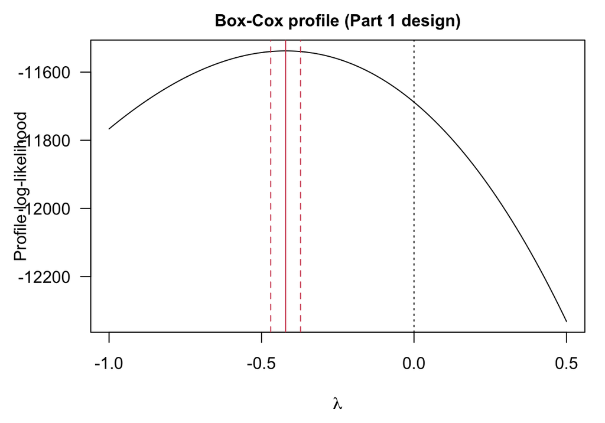

```r
par(mar = c(4.5, 4.5, 2, 1), las = 1)
plot(bc$x, bc$y, type = "l", xlab = expression(lambda), ylab = "Profile log-likelihood",
     main = "Box-Cox profile (Part 1 design)", cex.main = 1)
abline(v = c(lambda_hat, lambda_ci), lty = c(1, 2, 2), col = ln_col)
abline(v = 0, lty = 3)
```

λ̂ ≈ -0.421，95% CI 为 (-0.470, -0.372)，**不含 0**。说明需要比 log 更强一点的压缩。下一节比较 log（λ = 0， 便于按百分比解释）与 λ = −0.5（最接近 λ̂ 的”整齐”值）。

# 4 变换方案比较：log–线性、log–log、λ = −0.5

```r
train$bc_m05 <- -2 * (train$price_k^-0.5 - 1)      # Box-Cox lambda = -0.5, increasing in price
f_loglin <- as.formula(paste("log_price ~ sqft100 * division +", ctrl_all))
f_loglog <- as.formula(paste("log_price ~ log_sqft * division +", ctrl_all))
f_bc05   <- as.formula(paste("bc_m05 ~ sqft100 * division +", ctrl_all))
m_loglin <- lm(f_loglin, data = train)
m_loglog <- lm(f_loglog, data = train)
m_bc05   <- lm(f_bc05, data = train)
cmp_row <- function(m) {
  e <- resid(m); bp <- bp_koenker(m)
  c(R2 = r2(m), adjR2 = adjr2(m), BIC = BIC(m), resid_skew = skew(e), resid_exkurt = exkurt(e),
    BP_LM = unname(bp["LM"]), BP_p = unname(bp["p"]),
    int_HC3_p = unname(hc3_test(m, update(m, as.formula(paste(". ~ . -",
                 grep(":division$|:division", attr(terms(m), "term.labels"), value = TRUE)))))["p"]))
}
trans_tab <- rbind(`Part 1: price ~ sqft` = cmp_row(m1), `log(price) ~ sqft` = cmp_row(m_loglin),
                   `log(price) ~ log(sqft)` = cmp_row(m_loglog),
                   `BoxCox(-0.5) ~ sqft` = cmp_row(m_bc05))
trans_show <- data.frame(round(trans_tab[, 1:6], 4), BP_p = fp(trans_tab[, "BP_p"]),
                         int_HC3_p = fp(trans_tab[, "int_HC3_p"]), check.names = FALSE)
knitr::kable(trans_show,
             caption = "变换方案比较（BIC 为 R 的 BIC()，只在同一响应变量之间可比）")
```

变换方案比较（BIC 为 R 的 BIC()，只在同一响应变量之间可比）

|  | R2 | adjR2 | BIC | resid_skew | resid_exkurt | BP_LM | BP_p | int_HC3_p |
| --- | --- | --- | --- | --- | --- | --- | --- | --- |
| Part 1: price ~ sqft | 0.7133 | 0.7098 | 56927.9877 | 2.0445 | 18.0050 | 1280.5839 | 1.62e-234 | 7.52e-24 |
| log(price) ~ sqft | 0.7457 | 0.7426 | -148.6444 | 0.5483 | 2.6424 | 523.4180 | 1.35e-79 | 1.88e-06 |
| log(price) ~ log(sqft) | 0.7573 | 0.7544 | -351.0672 | 0.4806 | 2.5941 | 521.6144 | 3.06e-79 | 1.14e-10 |
| BoxCox(-0.5) ~ sqft | 0.7322 | 0.7290 | -27080.2331 | 0.1555 | 1.5464 | 315.6209 | 7.97e-40 | 1.11e-12 |

```r
# curvature in floor area on the log scale: add a squared term to the log-linear model
m_loglin_sq <- update(m_loglin, . ~ . + I(sqft100^2))
sq_test <- pf_test(m_loglin_sq, m_loglin)
c(sq_test, coef_sq = unname(coef(m_loglin_sq)["I(sqft100^2)"]))
```

```
#>             F            df             p           dR2       coef_sq
#>  2.282633e+02  1.000000e+00  2.771989e-50  1.288604e-02 -3.336143e-04
```

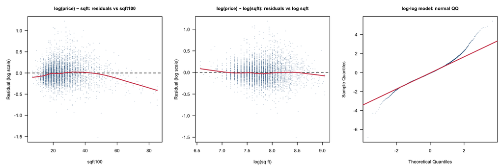

```r
draw_trans <- function() {
  par(mfrow = c(1, 3), mar = c(4.5, 5, 3, 1), las = 1)
  plot(train$sqft100, resid(m_loglin), pch = 16, cex = 0.4, col = pt_col,
       xlab = "sqft100", ylab = "Residual (log scale)", main = "log(price) ~ sqft: residuals vs sqft100",
       cex.main = 1)
  abline(h = 0, lty = 2); lines(lowess(train$sqft100, resid(m_loglin), f = 0.3), col = ln_col, lwd = 2)
  plot(train$log_sqft, resid(m_loglog), pch = 16, cex = 0.4, col = pt_col,
       xlab = "log(sq ft)", ylab = "Residual (log scale)", main = "log(price) ~ log(sqft): residuals vs log sqft",
       cex.main = 1)
  abline(h = 0, lty = 2); lines(lowess(train$log_sqft, resid(m_loglog), f = 0.3), col = ln_col, lwd = 2)
  qqnorm(rstandard(m_loglog), pch = 16, cex = 0.4, col = pt_col, main = "log-log model: normal QQ",
         cex.main = 1)
  qqline(rstandard(m_loglog), col = ln_col, lwd = 2)
}
fig_out("part2_transform_check.png", 12, 4, draw_trans)
```

**结论**：log 变换把残差偏度从 2.04 降到约 0.5、超额峰度从 18 降到约 2.6；λ = −0.5 更接近正态，但系数难以解释。 log–线性模型在面积上仍有明显凹形（平方项 F = 228.3，p = 2.8e-50），而 log–log 的 BIC 更低（-351.1 对 -148.6），所以采用 **log(价格) ~ log(面积)**，面积斜率解释为弹性。

# 5 多重共线性（VIF / GVIF）

`car::vif()` 对多水平类别变量给出 GVIF 和 GVIF^(1/(2·Df))。含交互的模型会出现”结构性”共线（交互列与主效应列 高度相关），这不是数据问题；把 log 面积减去训练集均值（中心化）后即可消除。

```r
vif_tab <- function(m) {
  v <- suppressMessages(vif(m, type = "terms"))
  v <- if (is.matrix(v)) v else cbind(GVIF = v, Df = 1, `GVIF^(1/(2*Df))` = sqrt(v))
  v[order(-v[, 3]), , drop = FALSE]
}
m1_main <- update(m1, . ~ . - sqft100:division)
m_loglog_main <- update(m_loglog, . ~ . - log_sqft:division)
train$log_sqft_c <- train$log_sqft - mean(train$log_sqft)
m_loglog_c <- lm(as.formula(paste("log_price ~ log_sqft_c * division +", ctrl_all)), data = train)
knitr::kable(head(vif_tab(m1_main), 5), digits = 3, caption = "Part 1 模型（只含主效应）")
```

Part 1 模型（只含主效应）

|  | GVIF | Df | GVIF^(1/(2*Df)) |
| --- | --- | --- | --- |
| sqft100 | 3.393 | 1 | 1.842 |
| lot_k | 1.685 | 1 | 1.298 |
| sewer | 1.620 | 1 | 1.273 |
| fullbath | 4.031 | 3 | 1.262 |
| bedrooms | 3.076 | 3 | 1.206 |

```r
knitr::kable(head(vif_tab(m1), 4), digits = 3, caption = "Part 1 模型（含交互）")
```

Part 1 模型（含交互）

|  | GVIF | Df | GVIF^(1/(2*Df)) |
| --- | --- | --- | --- |
| division | 22227788.875 | 8 | 2.879 |
| sqft100:division | 18291918.700 | 8 | 2.844 |
| sqft100 | 6.194 | 1 | 2.489 |
| lot_k | 1.698 | 1 | 1.303 |

```r
knitr::kable(head(vif_tab(m_loglog_main), 4), digits = 3, caption = "log–log 模型（只含主效应）")
```

log–log 模型（只含主效应）

|  | GVIF | Df | GVIF^(1/(2*Df)) |
| --- | --- | --- | --- |
| log_sqft | 3.628 | 1 | 1.905 |
| lot_k | 1.679 | 1 | 1.296 |
| sewer | 1.620 | 1 | 1.273 |
| fullbath | 3.935 | 3 | 1.256 |

```r
knitr::kable(head(vif_tab(m_loglog), 4), digits = 3, caption = "log–log 模型（含交互，未中心化）")
```

log–log 模型（含交互，未中心化）

|  | GVIF | Df | GVIF^(1/(2*Df)) |
| --- | --- | --- | --- |
| division | 3.603269e+21 | 8 | 22.248 |
| log_sqft:division | 3.545951e+21 | 8 | 22.226 |
| log_sqft | 6.841000e+00 | 1 | 2.616 |
| lot_k | 1.692000e+00 | 1 | 1.301 |

```r
knitr::kable(head(vif_tab(m_loglog_c), 4), digits = 3, caption = "log–log 模型（含交互，log 面积中心化）")
```

log–log 模型（含交互，log 面积中心化）

|  | GVIF | Df | GVIF^(1/(2*Df)) |
| --- | --- | --- | --- |
| log_sqft_c | 6.841 | 1 | 2.616 |
| lot_k | 1.692 | 1 | 1.301 |
| sewer | 1.631 | 1 | 1.277 |
| fullbath | 4.257 | 3 | 1.273 |

中心化只改变截距和 division 主效应的含义，不改变拟合值、交互系数和各组弹性。

# 6 变量选择

## 6.1 各候选变量的 partial F（`drop1` / `anova`）

完整 log–log 模型中逐个去掉一个变量的 partial F 检验（其余变量保留）：

```r
d1 <- drop1(m_loglog, scope = ~ stories + bedrooms + fullbath + halfbath + garage + foundation +
              fireplace + hoa + age_restricted + wall + heat_fuel + sewer + stage + sale_month + lot_k,
            test = "F")
d1[order(-d1[, "Pr(>F)"]), ]
```

```
#> Single term deletions
#>
#> Model:
#> log_price ~ log_sqft * division + lot_k + stories + bedrooms +
#>     fullbath + halfbath + garage + foundation + fireplace + hoa +
#>     age_restricted + wall + heat_fuel + sewer + stage + sale_month
#>                Df Sum of Sq    RSS    AIC F value    Pr(>F)
#> hoa             1    0.0012 211.00 -12981  0.0248 0.8749196
#> age_restricted  1    0.1099 211.11 -12979  2.2279 0.1356119
#> sewer           1    0.1212 211.12 -12978  2.4577 0.1170253
#> sale_month      1    0.1445 211.15 -12978  2.9287 0.0870892 .
#> lot_k           1    0.4672 211.47 -12971  9.4732 0.0020981 **
#> stage           2    0.6847 211.69 -12969  6.9409 0.0009783 ***
#> heat_fuel       3    1.5641 212.57 -12953 10.5707 6.358e-07 ***
#> garage          3    1.7108 212.72 -12950 11.5615 1.517e-07 ***
#> wall            6    2.9608 213.97 -12930 10.0047 5.330e-11 ***
#> halfbath        2    2.5817 213.59 -12930 26.1715 5.044e-12 ***
#> bedrooms        3    3.7371 214.74 -12909 25.2562 3.425e-16 ***
#> stories         2    3.5443 214.55 -12911 35.9295 3.355e-16 ***
#> foundation      3    6.2696 217.27 -12858 42.3710 < 2.2e-16 ***
#> fireplace       2    9.7551 220.76 -12787 98.8900 < 2.2e-16 ***
#> fullbath        3   14.4143 225.42 -12699 97.4140 < 2.2e-16 ***
#> <none>                      211.00 -12979
#> ---
#> Signif. codes:  0 '***' 0.001 '**' 0.01 '*' 0.05 '.' 0.1 ' ' 1
```

```r
# the research-question terms: interaction, and X + interaction
rbind(interaction = pf_test(m_loglog, update(m_loglog, . ~ . - log_sqft:division)),
      area_and_interaction = pf_test(m_loglog, update(m_loglog, . ~ . - log_sqft:division - log_sqft)))
```

```
#>                               F df             p         dR2
#> interaction            7.315477  8  1.064968e-09 0.003320417
#> area_and_interaction 141.537575  9 1.698897e-234 0.072272687
```

## 6.2 后向逐步回归：AIC 与 BIC（`step()`）

**强制保留**：`log_sqft`、`division`、`log_sqft:division`（研究问题本身）和 `lot_k`（hedonic 理论：土地是价格 的一部分）。用 `scope` 的 `lower` 实现。BIC 用 `k = log(n)`。

```r
lower_f <- ~ log_sqft * division + lot_k
sel_aic <- step(m_loglog, scope = list(lower = lower_f, upper = formula(m_loglog)),
                direction = "backward", k = 2, trace = 0)
sel_bic <- step(m_loglog, scope = list(lower = lower_f, upper = formula(m_loglog)),
                direction = "backward", k = log(n), trace = 0)
sel_aic$anova
```

```
#>    Step Df   Deviance Resid. Df Resid. Dev       AIC
#> 1       NA         NA      4278   211.0040 -12978.86
#> 2 - hoa  1 0.00122231      4279   211.0052 -12980.84
```

```r
sel_bic$anova
```

```
#>               Step Df   Deviance Resid. Df Resid. Dev       AIC
#> 1                  NA         NA      4278   211.0040 -12647.45
#> 2            - hoa  1 0.00122231      4279   211.0052 -12655.80
#> 3 - age_restricted  1 0.11191681      4280   211.1171 -12661.87
#> 4          - sewer  1 0.13934106      4281   211.2564 -12667.39
#> 5     - sale_month  1 0.14039391      4282   211.3968 -12672.89
#> 6          - stage  2 0.69905082      4284   212.0959 -12675.34
```

```r
# replay each path: partial F of the dropped term, R^2 and adj R^2 after each step
replay <- function(start, path, k) {
  drops <- sub("^- ", "", as.character(path$Step[-1]))
  cur <- start
  out <- data.frame(step = 0, dropped = "(full log-log model)", criterion = extractAIC(cur, k = k)[2],
                    BIC_R = BIC(cur), df = NA, F = NA, p = NA, R2 = r2(cur), adjR2 = adjr2(cur))
  for (i in seq_along(drops)) {
    new <- update(cur, as.formula(paste(". ~ . -", drops[i])))
    a <- anova(new, cur)
    out <- rbind(out, data.frame(step = i, dropped = drops[i], criterion = extractAIC(new, k = k)[2],
                                 BIC_R = BIC(new), df = a$Df[2], F = a$F[2], p = a[2, "Pr(>F)"],
                                 R2 = r2(new), adjR2 = adjr2(new)))
    cur <- new
  }
  out
}
hist_bic <- replay(m_loglog, sel_bic$anova, log(n))
hist_aic <- replay(m_loglog, sel_aic$anova, 2)
knitr::kable(hist_bic, digits = c(0, 0, 3, 3, 0, 3, 5, 5, 5),
             caption = "BIC 后向选择每一步（criterion = extractAIC(k = log n)，即 step() 实际最小化的量）")
```

BIC 后向选择每一步（criterion = extractAIC(k = log n)，即 step() 实际最小化的量）

| step | dropped | criterion | BIC_R | df | F | p | R2 | adjR2 |
| --- | --- | --- | --- | --- | --- | --- | --- | --- |
| 0 | (full log-log model) | -12647.45 | -351.067 | NA | NA | NA | 0.75728 | 0.75439 |
| 1 | hoa | -12655.80 | -359.415 | 1 | 0.025 | 0.87492 | 0.75728 | 0.75445 |
| 2 | age_restricted | -12661.87 | -365.493 | 1 | 2.270 | 0.13201 | 0.75715 | 0.75437 |
| 3 | sewer | -12667.39 | -371.009 | 1 | 2.825 | 0.09289 | 0.75699 | 0.75427 |
| 4 | sale_month | -12672.89 | -376.506 | 1 | 2.845 | 0.09173 | 0.75683 | 0.75416 |
| 5 | stage | -12675.34 | -378.958 | 2 | 7.080 | 0.00085 | 0.75603 | 0.75346 |

```r
knitr::kable(hist_aic, digits = c(0, 0, 3, 3, 0, 3, 5, 5, 5), caption = "AIC 后向选择每一步")
```

AIC 后向选择每一步

| step | dropped | criterion | BIC_R | df | F | p | R2 | adjR2 |
| --- | --- | --- | --- | --- | --- | --- | --- | --- |
| 0 | (full log-log model) | -12978.86 | -351.067 | NA | NA | NA | 0.75728 | 0.75439 |
| 1 | hoa | -12980.84 | -359.415 | 1 | 0.025 | 0.87492 | 0.75728 | 0.75445 |

```r
# joint partial F: are the BIC-dropped terms jointly needed?
anova(sel_bic, m_loglog)
```

```
#> Analysis of Variance Table
#>
#> Model 1: log_price ~ log_sqft + division + lot_k + stories + bedrooms +
#>     fullbath + halfbath + garage + foundation + fireplace + wall +
#>     heat_fuel + log_sqft:division
#> Model 2: log_price ~ log_sqft * division + lot_k + stories + bedrooms +
#>     fullbath + halfbath + garage + foundation + fireplace + hoa +
#>     age_restricted + wall + heat_fuel + sewer + stage + sale_month
#>   Res.Df   RSS Df Sum of Sq      F   Pr(>F)
#> 1   4284 212.1
#> 2   4278 211.0  6    1.0919 3.6897 0.001166 **
#> ---
#> Signif. codes:  0 '***' 0.001 '**' 0.01 '*' 0.05 '.' 0.1 ' ' 1
```

BIC 依次删去 hoa、age_restricted、sewer、sale_month、stage；AIC 只删去 hoa。注意 `stage` 单独的 partial F p 很小（见上表），被 BIC 删掉是 因为 BIC 的惩罚 log(n) ≈ 8.37 较重；两种选择下 adj R² 只差约 0.001。我们采用更简约的 BIC 模型为最终模型，AIC 模型作为对照（两者的交互结论相同，见下文）。

# 7 最终模型（log–log，BIC 选择）

```r
ctrl_fin <- "lot_k + stories + bedrooms + fullbath + halfbath + garage + foundation + fireplace + wall + heat_fuel"
f_final <- as.formula(paste("log_price ~ log_sqft * division +", ctrl_fin))
m2 <- lm(f_final, data = train)
stopifnot(setequal(attr(terms(m2), "term.labels"), attr(terms(sel_bic), "term.labels")))
m2_noint <- update(m2, . ~ . - log_sqft:division)
m2_noX <- update(m2, . ~ . - log_sqft:division - log_sqft)
s2 <- summary(m2)
c(coefficients = length(coef(m2)), R2 = s2$r.squared, adjR2 = s2$adj.r.squared, sigma = s2$sigma,
  F = unname(s2$fstatistic[1]))
```

```
#> coefficients           R2        adjR2        sigma            F
#>   46.0000000    0.7560267    0.7534639    0.2225058  295.0065806
```

```r
p2_int_F <- pf_test(m2, m2_noint); p2_int_hc3 <- hc3_test(m2, m2_noint); p2_X <- pf_test(m2, m2_noX)
rbind(partial_F = p2_int_F[c("F", "df", "p")], HC3_Wald = p2_int_hc3)
```

```
#>                  F df            p
#> partial_F 7.087779  8 2.389831e-09
#> HC3_Wald  7.847103  8 1.598175e-10
```

```r
c(dR2_interaction = unname(p2_int_F["dR2"]), dR2_area_and_interaction = unname(p2_X["dR2"]))
```

```
#>          dR2_interaction dR2_area_and_interaction
#>              0.003229186              0.076151116
```

```r
el <- div_slopes(m2, "log_sqft")
el_hc3 <- div_slopes(m2, "log_sqft", V = vcov_hc3(m2))
el_tab <- data.frame(n = as.vector(table(train$division)[division_levels]), elasticity = el[, "est"],
                     lower95 = el[, "lower"], upper95 = el[, "upper"], se_HC3 = el_hc3[, "se"],
                     p_HC3 = fp(el_hc3[, "p"]), pct_price_per_10pct_area = 100 * (1.1^el[, "est"] - 1))
knitr::kable(el_tab, digits = c(0, 3, 3, 3, 3, 0, 2), caption = "最终模型：各 division 的面积弹性")
```

最终模型：各 division 的面积弹性

|  | n | elasticity | lower95 | upper95 | se_HC3 | p_HC3 | pct_price_per_10pct_area |
| --- | --- | --- | --- | --- | --- | --- | --- |
| SouthAtlantic | 1308 | 0.679 | 0.630 | 0.727 | 0.028 | 1.50e-120 | 6.68 |
| NewEngland | 39 | 0.632 | 0.448 | 0.815 | 0.097 | 7.34e-11 | 6.20 |
| MidAtlantic | 119 | 0.735 | 0.633 | 0.837 | 0.084 | 2.72e-18 | 7.26 |
| ENCentral | 510 | 0.525 | 0.462 | 0.589 | 0.030 | 3.74e-68 | 5.13 |
| WNCentral | 313 | 0.535 | 0.462 | 0.608 | 0.041 | 1.26e-38 | 5.23 |
| ESCentral | 344 | 0.702 | 0.628 | 0.775 | 0.041 | 1.66e-63 | 6.92 |
| WSCentral | 850 | 0.734 | 0.677 | 0.791 | 0.029 | 2.56e-134 | 7.24 |
| Mountain | 473 | 0.584 | 0.523 | 0.645 | 0.032 | 1.51e-70 | 5.73 |
| Pacific | 374 | 0.727 | 0.650 | 0.804 | 0.039 | 5.34e-75 | 7.18 |

```r
ci2 <- confint(m2)
final_coef <- data.frame(term = names(coef(m2)), estimate = coef(m2), se = s2$coefficients[, 2],
                         lower95 = ci2[, 1], upper95 = ci2[, 2],
                         se_HC3 = sqrt(diag(vcov_hc3(m2))), row.names = NULL)
knitr::kable(final_coef, digits = 4, caption = "最终模型全部 46 个系数")
```

最终模型全部 46 个系数

| term | estimate | se | lower95 | upper95 | se_HC3 |
| --- | --- | --- | --- | --- | --- |
| (Intercept) | 0.8268 | 0.1923 | 0.4497 | 1.2039 | 0.2149 |
| log_sqft | 0.6786 | 0.0248 | 0.6299 | 0.7273 | 0.0281 |
| divisionNewEngland | 1.0144 | 0.7541 | -0.4640 | 2.4928 | 0.7795 |
| divisionMidAtlantic | -0.1706 | 0.4246 | -1.0029 | 0.6618 | 0.6698 |
| divisionENCentral | 1.2063 | 0.2705 | 0.6761 | 1.7365 | 0.2483 |
| divisionWNCentral | 1.0968 | 0.3135 | 0.4821 | 1.7115 | 0.3244 |
| divisionESCentral | -0.2146 | 0.2994 | -0.8016 | 0.3724 | 0.3209 |
| divisionWSCentral | -0.4810 | 0.2382 | -0.9480 | -0.0141 | 0.2222 |
| divisionMountain | 1.0090 | 0.2660 | 0.4876 | 1.5304 | 0.2731 |
| divisionPacific | -0.0341 | 0.3216 | -0.6646 | 0.5964 | 0.3213 |
| lot_k | 0.0006 | 0.0002 | 0.0001 | 0.0010 | 0.0003 |
| stories2 | -0.0363 | 0.0094 | -0.0548 | -0.0178 | 0.0101 |
| stories3plus | 0.1505 | 0.0263 | 0.0991 | 0.2020 | 0.0441 |
| bedrooms3 | -0.1128 | 0.0205 | -0.1530 | -0.0726 | 0.0198 |
| bedrooms4 | -0.1669 | 0.0217 | -0.2094 | -0.1243 | 0.0208 |
| bedrooms5plus | -0.2201 | 0.0250 | -0.2691 | -0.1712 | 0.0252 |
| fullbath2 | 0.0253 | 0.0370 | -0.0473 | 0.0979 | 0.0485 |
| fullbath3 | 0.1427 | 0.0388 | 0.0667 | 0.2187 | 0.0503 |
| fullbath4plus | 0.3397 | 0.0415 | 0.2583 | 0.4210 | 0.0530 |
| halfbath1 | 0.0635 | 0.0092 | 0.0455 | 0.0816 | 0.0101 |
| halfbath2plus | 0.1212 | 0.0317 | 0.0591 | 0.1832 | 0.0397 |
| garage2car | -0.0145 | 0.0192 | -0.0522 | 0.0231 | 0.0255 |
| garage3plus | 0.0430 | 0.0216 | 0.0007 | 0.0853 | 0.0277 |
| garageother | 0.0054 | 0.0271 | -0.0476 | 0.0584 | 0.0342 |
| foundationcrawl | 0.0693 | 0.0150 | 0.0399 | 0.0988 | 0.0181 |
| foundationslab | -0.0730 | 0.0115 | -0.0955 | -0.0505 | 0.0129 |
| foundationother | -0.0239 | 0.0773 | -0.1754 | 0.1276 | 0.0758 |
| fireplace1 | 0.1173 | 0.0088 | 0.1001 | 0.1345 | 0.0095 |
| fireplace2plus | 0.1314 | 0.0194 | 0.0934 | 0.1694 | 0.0232 |
| wallwood | 0.0020 | 0.0211 | -0.0394 | 0.0433 | 0.0226 |
| wallstucco | 0.0294 | 0.0147 | 0.0006 | 0.0582 | 0.0162 |
| wallvinyl | -0.0462 | 0.0130 | -0.0717 | -0.0207 | 0.0133 |
| wallstone | 0.0381 | 0.0312 | -0.0231 | 0.0993 | 0.0346 |
| wallfibercement | 0.0225 | 0.0127 | -0.0023 | 0.0474 | 0.0136 |
| wallother | 0.1177 | 0.0609 | -0.0018 | 0.2371 | 0.0606 |
| heat_fuelgas | 0.0547 | 0.0090 | 0.0370 | 0.0725 | 0.0092 |
| heat_fuelpropane | -0.0163 | 0.0359 | -0.0868 | 0.0541 | 0.0422 |
| heat_fuelother | 0.0266 | 0.0344 | -0.0408 | 0.0940 | 0.0253 |
| log_sqft:divisionNewEngland | -0.0471 | 0.0940 | -0.2313 | 0.1371 | 0.0969 |
| log_sqft:divisionMidAtlantic | 0.0564 | 0.0535 | -0.0484 | 0.1612 | 0.0852 |
| log_sqft:divisionENCentral | -0.1533 | 0.0347 | -0.2213 | -0.0853 | 0.0321 |
| log_sqft:divisionWNCentral | -0.1436 | 0.0405 | -0.2230 | -0.0642 | 0.0426 |
| log_sqft:divisionESCentral | 0.0232 | 0.0386 | -0.0524 | 0.0988 | 0.0419 |
| log_sqft:divisionWSCentral | 0.0552 | 0.0306 | -0.0047 | 0.1151 | 0.0288 |
| log_sqft:divisionMountain | -0.0944 | 0.0340 | -0.1611 | -0.0277 | 0.0354 |
| log_sqft:divisionPacific | 0.0486 | 0.0415 | -0.0328 | 0.1301 | 0.0420 |

## 7.1 最终模型的多重共线性

```r
m2_c <- lm(as.formula(paste("log_price ~ log_sqft_c * division +", ctrl_fin)), data = train)
knitr::kable(head(vif_tab(m2_noint), 4), digits = 3, caption = "最终模型（只含主效应）")
```

最终模型（只含主效应）

|  | GVIF | Df | GVIF^(1/(2*Df)) |
| --- | --- | --- | --- |
| log_sqft | 3.540 | 1 | 1.882 |
| fullbath | 3.891 | 3 | 1.254 |
| stories | 2.083 | 2 | 1.201 |
| bedrooms | 2.874 | 3 | 1.192 |

```r
knitr::kable(head(vif_tab(m2), 4), digits = 3, caption = "最终模型（含交互，未中心化）")
```

最终模型（含交互，未中心化）

|  | GVIF | Df | GVIF^(1/(2*Df)) |
| --- | --- | --- | --- |
| division | 3.491929e+21 | 8 | 22.205 |
| log_sqft:division | 3.439849e+21 | 8 | 22.184 |
| log_sqft | 6.695000e+00 | 1 | 2.587 |
| fullbath | 4.210000e+00 | 3 | 1.271 |

```r
knitr::kable(head(vif_tab(m2_c), 4), digits = 3, caption = "最终模型（含交互，log 面积中心化）")
```

最终模型（含交互，log 面积中心化）

|  | GVIF | Df | GVIF^(1/(2*Df)) |
| --- | --- | --- | --- |
| log_sqft_c | 6.695 | 1 | 2.587 |
| fullbath | 4.210 | 3 | 1.271 |
| stories | 2.159 | 2 | 1.212 |
| division | 20.202 | 8 | 1.207 |

```r
c(max_abs_diff_fitted_centred_vs_not = max(abs(fitted(m2_c) - fitted(m2))))
```

```
#> max_abs_diff_fitted_centred_vs_not
#>                       2.815526e-13
```

主效应模型中最大的 GVIF^(1/(2Df)) 不到 2，没有需要处理的多重共线性；含交互时的大 GVIF 是结构性的，中心化后消失， 而拟合值完全不变。

## 7.2 最终模型的残差诊断

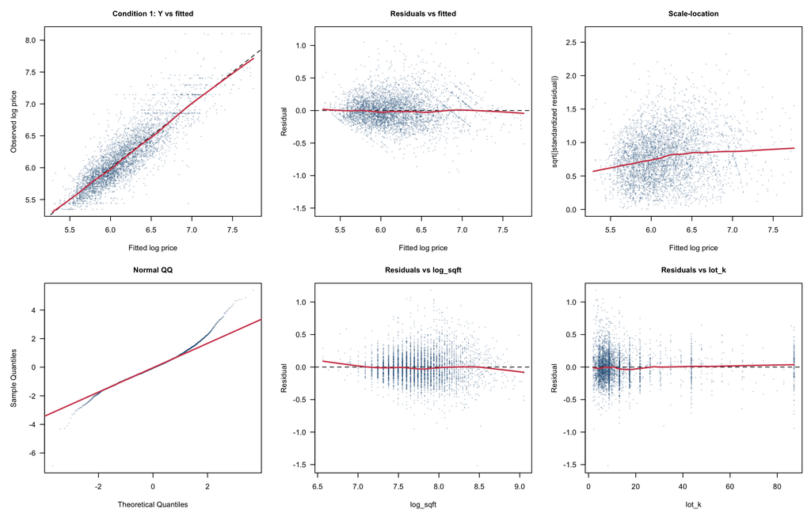

```r
e2 <- resid(m2); yhat2 <- fitted(m2); r2s <- rstandard(m2)
draw_final <- function() {
  par(mfrow = c(2, 3), mar = c(4.5, 5, 3, 1), las = 1)
  plot(yhat2, train$log_price, pch = 16, cex = 0.4, col = pt_col, xlab = "Fitted log price",
       ylab = "Observed log price", main = "Condition 1: Y vs fitted", cex.main = 1)
  abline(0, 1, lty = 2); lines(lowess(yhat2, train$log_price, f = 0.3), col = ln_col, lwd = 2)
  plot(yhat2, e2, pch = 16, cex = 0.4, col = pt_col, xlab = "Fitted log price", ylab = "Residual",
       main = "Residuals vs fitted", cex.main = 1)
  abline(h = 0, lty = 2); lines(lowess(yhat2, e2, f = 0.3), col = ln_col, lwd = 2)
  plot(yhat2, sqrt(abs(r2s)), pch = 16, cex = 0.4, col = pt_col, xlab = "Fitted log price",
       ylab = "sqrt(|standardized residual|)", main = "Scale-location", cex.main = 1)
  lines(lowess(yhat2, sqrt(abs(r2s)), f = 0.3), col = ln_col, lwd = 2)
  qqnorm(r2s, pch = 16, cex = 0.4, col = pt_col, main = "Normal QQ", cex.main = 1)
  qqline(r2s, col = ln_col, lwd = 2)
  for (v in c("log_sqft", "lot_k")) {
    plot(train[[v]], e2, pch = 16, cex = 0.4, col = pt_col, xlab = v, ylab = "Residual",
         main = paste("Residuals vs", v), cex.main = 1)
    abline(h = 0, lty = 2); lines(lowess(train[[v]], e2, f = 0.3), col = ln_col, lwd = 2)
  }
}
fig_out("part2_final_residuals.png", 12, 7.6, draw_final)
```

```
#>   division    stories   bedrooms   fullbath   halfbath     garage foundation  fireplace       wall  heat_fuel
#>       2.23       2.07       1.26       1.48       1.39       1.43       1.41       1.26       1.24       1.57
```

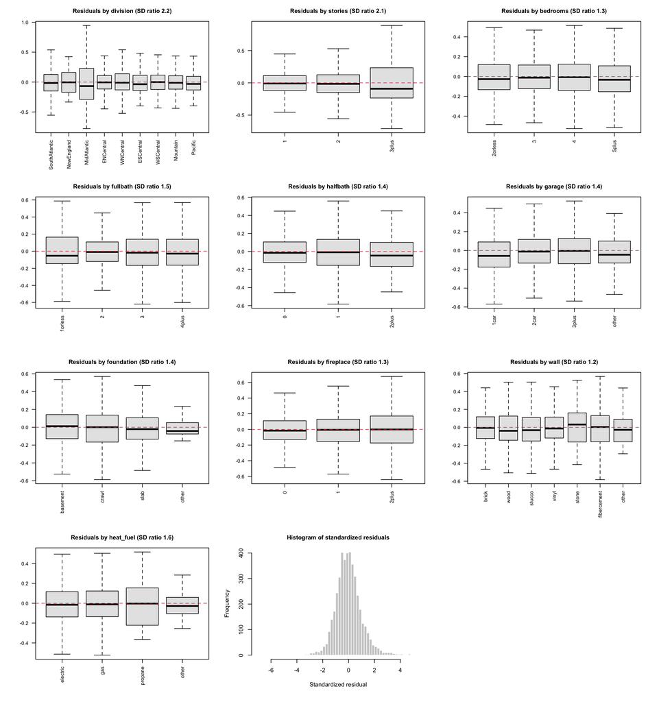

```r
cat_fin <- c("division", "stories", "bedrooms", "fullbath", "halfbath", "garage", "foundation",
             "fireplace", "wall", "heat_fuel")
sd_ratio2 <- sapply(cat_fin, function(v) { s <- tapply(e2, train[[v]], sd); max(s) / min(s) })
draw_final_box <- function() {
  par(mfrow = c(4, 3), mar = c(6, 5, 3, 1))
  for (v in cat_fin) {
    boxplot(e2 ~ train[[v]], outline = FALSE, las = 2, cex.axis = 0.85, xlab = "", ylab = "",
            col = "grey90", main = sprintf("Residuals by %s (SD ratio %.1f)", v, sd_ratio2[v]),
            cex.main = 1)
    abline(h = 0, col = ln_col, lty = 2)
  }
  hist(r2s, breaks = 80, col = "grey80", border = "white", xlab = "Standardized residual",
       main = "Histogram of standardized residuals", cex.main = 1)
}
fig_out("part2_final_resid_by_categorical.png", 12, 13, draw_final_box)
round(sd_ratio2, 2)
```

# 8 影响点与离群点（Part 1 模型 vs 最终模型）

阈值：杠杆值 2p/n；标准化残差 |r| > 4（n 很大时课程用 4）；Cook’s D > 4/n 和 > F(0.5; p, n−p)； |DFFITS| > 2√(p/n)；|DFBETAS| > 2/√n（只看面积与交互系数）。

```r
infl_table <- function(m, focal) {
  N <- nobs(m); p <- length(coef(m))
  h <- hatvalues(m); r <- rstandard(m); cd <- cooks.distance(m); dff <- dffits(m)
  dfb <- dfbetas(m)[, focal, drop = FALSE]
  base <- data.frame(
    measure = c("leverage h_ii", "|standardized residual|", "Cook's D", "Cook's D", "|DFFITS|"),
    cutoff_rule = c("2p/n", "4", "4/n", "F(0.5; p, n-p)", "2*sqrt(p/n)"),
    cutoff = c(2 * p / N, 4, 4 / N, qf(0.5, p, N - p), 2 * sqrt(p / N)),
    n_beyond = c(sum(h > 2 * p / N), sum(abs(r) > 4), sum(cd > 4 / N), sum(cd > qf(0.5, p, N - p)),
                 sum(abs(dff) > 2 * sqrt(p / N))),
    max_value = c(max(h), max(abs(r)), max(cd), max(cd), max(abs(dff))))
  fb <- data.frame(measure = paste("|DFBETAS|", focal), cutoff_rule = "2/sqrt(n)",
                   cutoff = 2 / sqrt(N), n_beyond = colSums(abs(dfb) > 2 / sqrt(N)),
                   max_value = apply(abs(dfb), 2, max), row.names = NULL)
  rbind(base, fb)
}
focal1 <- c("sqft100", paste0("sqft100:division", division_levels[-1]))
focal2 <- c("log_sqft", paste0("log_sqft:division", division_levels[-1]))
infl1 <- infl_table(m1, focal1); infl2 <- infl_table(m2, focal2)
knitr::kable(infl1, digits = 4, caption = "Part 1 模型（原始售价）")
```

Part 1 模型（原始售价）

| measure | cutoff_rule | cutoff | n_beyond | max_value |
| --- | --- | --- | --- | --- |
| leverage h_ii | 2p/n | 0.0240 | 349 | 0.3638 |
| \|standardized residual\| | 4 | 4.0000 | 36 | 12.0557 |
| Cook’s D | 4/n | 0.0009 | 313 | 0.1845 |
| Cook’s D | F(0.5; p, n-p) | 0.9874 | 0 | 0.1845 |
| \|DFFITS\| | 2*sqrt(p/n) | 0.2192 | 313 | 3.1167 |
| \|DFBETAS\| sqft100 | 2/sqrt(n) | 0.0304 | 239 | 0.2748 |
| \|DFBETAS\| sqft100:divisionNewEngland | 2/sqrt(n) | 0.0304 | 64 | 2.2658 |
| \|DFBETAS\| sqft100:divisionMidAtlantic | 2/sqrt(n) | 0.0304 | 124 | 2.6320 |
| \|DFBETAS\| sqft100:divisionENCentral | 2/sqrt(n) | 0.0304 | 161 | 0.5940 |
| \|DFBETAS\| sqft100:divisionWNCentral | 2/sqrt(n) | 0.0304 | 136 | 0.3849 |
| \|DFBETAS\| sqft100:divisionESCentral | 2/sqrt(n) | 0.0304 | 137 | 0.3821 |
| \|DFBETAS\| sqft100:divisionWSCentral | 2/sqrt(n) | 0.0304 | 172 | 0.2602 |
| \|DFBETAS\| sqft100:divisionMountain | 2/sqrt(n) | 0.0304 | 181 | 0.5887 |
| \|DFBETAS\| sqft100:divisionPacific | 2/sqrt(n) | 0.0304 | 141 | 0.3481 |

```r
knitr::kable(infl2, digits = 4, caption = "最终模型（log–log）")
```

最终模型（log–log）

| measure | cutoff_rule | cutoff | n_beyond | max_value |
| --- | --- | --- | --- | --- |
| leverage h_ii | 2p/n | 0.0212 | 414 | 0.1991 |
| \|standardized residual\| | 4 | 4.0000 | 17 | 6.9001 |
| Cook’s D | 4/n | 0.0009 | 291 | 0.0218 |
| Cook’s D | F(0.5; p, n-p) | 0.9857 | 0 | 0.0218 |
| \|DFFITS\| | 2*sqrt(p/n) | 0.2061 | 291 | 1.0068 |
| \|DFBETAS\| log_sqft | 2/sqrt(n) | 0.0304 | 266 | 0.2044 |
| \|DFBETAS\| log_sqft:divisionNewEngland | 2/sqrt(n) | 0.0304 | 53 | 0.6311 |
| \|DFBETAS\| log_sqft:divisionMidAtlantic | 2/sqrt(n) | 0.0304 | 106 | 0.5926 |
| \|DFBETAS\| log_sqft:divisionENCentral | 2/sqrt(n) | 0.0304 | 187 | 0.2715 |
| \|DFBETAS\| log_sqft:divisionWNCentral | 2/sqrt(n) | 0.0304 | 173 | 0.2102 |
| \|DFBETAS\| log_sqft:divisionESCentral | 2/sqrt(n) | 0.0304 | 140 | 0.2945 |
| \|DFBETAS\| log_sqft:divisionWSCentral | 2/sqrt(n) | 0.0304 | 197 | 0.2391 |
| \|DFBETAS\| log_sqft:divisionMountain | 2/sqrt(n) | 0.0304 | 194 | 0.2522 |
| \|DFBETAS\| log_sqft:divisionPacific | 2/sqrt(n) | 0.0304 | 143 | 0.2491 |

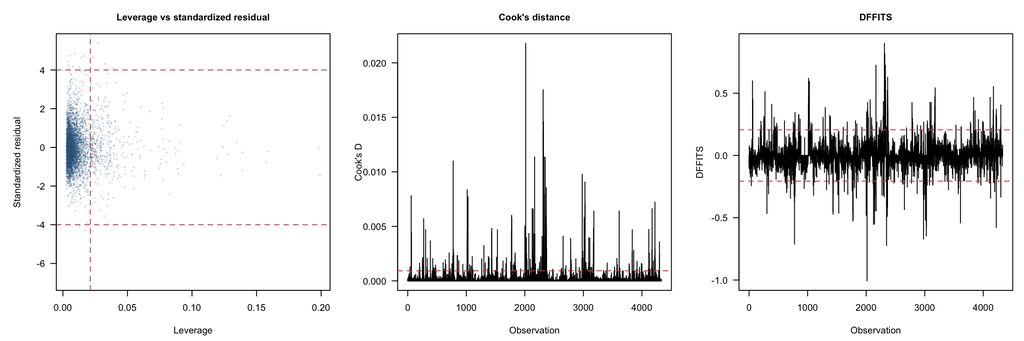

```r
draw_infl <- function() {
  N <- nobs(m2); p <- length(coef(m2))
  par(mfrow = c(1, 3), mar = c(4.5, 5, 3, 1), las = 1)
  plot(hatvalues(m2), rstandard(m2), pch = 16, cex = 0.4, col = pt_col, xlab = "Leverage",
       ylab = "Standardized residual", main = "Leverage vs standardized residual", cex.main = 1)
  abline(v = 2 * p / N, h = c(-4, 4), lty = 2, col = ln_col)
  plot(cooks.distance(m2), type = "h", xlab = "Observation", ylab = "Cook's D",
       main = "Cook's distance", cex.main = 1)
  abline(h = 4 / N, lty = 2, col = ln_col)
  plot(dffits(m2), type = "h", xlab = "Observation", ylab = "DFFITS", main = "DFFITS", cex.main = 1)
  abline(h = c(-1, 1) * 2 * sqrt(p / N), lty = 2, col = ln_col)
}
fig_out("part2_final_influence.png", 12, 4, draw_infl)
```

没有任何点的 Cook’s D 超过 F(0.5) 中位数阈值；最终模型最大 Cook’s D 只有 0.022，所以**不删除任何点**。超过 4/n 的点很多是 n 很大时的正常现象。

# 9 前后对比

```r
gvif_max <- function(m) max(vif_tab(m)[, 3])
ba_row <- function(m, m_noint, m_noX, int_term) {
  e <- resid(m); bp <- bp_koenker(m); pf <- pf_test(m, m_noint); h3 <- hc3_test(m, m_noint)
  c(coefficients = length(coef(m)), R2 = r2(m), adjR2 = adjr2(m), resid_skew = skew(e),
    resid_exkurt = exkurt(e), BP_LM = unname(bp["LM"]), max_cooks_D = max(cooks.distance(m)),
    n_abs_std_resid_gt4 = sum(abs(rstandard(m)) > 4), int_partialF_p = unname(pf["p"]),
    int_HC3_p = unname(h3["p"]), dR2_X_and_XxG = r2(m) - r2(m_noX), dR2_interaction = unname(pf["dR2"]),
    max_GVIF_adj_main_effects = gvif_max(m_noint))
}
before_after <- cbind(`Part 1 (raw price)` = ba_row(m1, m1_noint, m1_noX),
                      `Part 2 final (log-log, BIC)` = ba_row(m2, m2_noint, m2_noX))
ba_show <- apply(before_after, 2, function(x) formatC(x, digits = 4, format = "g"))
rownames(ba_show) <- rownames(before_after)
knitr::kable(ba_show, align = "r", caption = "Part 1 与 Part 2 最终模型对比（训练集）")
```

Part 1 与 Part 2 最终模型对比（训练集）

|  | Part 1 (raw price) | Part 2 final (log-log, BIC) |
| --- | --- | --- |
| coefficients | 52 | 46 |
| R2 | 0.7133 | 0.756 |
| adjR2 | 0.7098 | 0.7535 |
| resid_skew | 2.045 | 0.4765 |
| resid_exkurt | 18 | 2.519 |
| BP_LM | 1281 | 483.9 |
| max_cooks_D | 0.1845 | 0.0218 |
| n_abs_std_resid_gt4 | 36 | 17 |
| int_partialF_p | 1.181e-57 | 2.39e-09 |
| int_HC3_p | 7.516e-24 | 1.598e-10 |
| dR2_X_and_XxG | 0.07392 | 0.07615 |
| dR2_interaction | 0.01999 | 0.003229 |
| max_GVIF_adj_main_effects | 1.842 | 1.882 |

# 10 稳健标准误：HC3 与按 division 聚类

聚类只有 9 个（division），聚类稳健 SE 的自由度最多 8，**结果不可靠，只作参考**。为与 Python（statsmodels， `cov_type = "cluster"` 默认用正态分布）对照，同时报告正态（z）p 值和更保守的 t(8) p 值。

```r
V_hc3 <- vcov_hc3(m2)
V_cl <- vcovCL(m2, cluster = train$division, type = "HC1")   # G/(G-1) * (N-1)/(N-K) small-sample factor
int_terms <- paste0("log_sqft:division", division_levels[-1])
ct_ols <- coeftest(m2)[int_terms, ]
ct_hc3 <- coeftest(m2, vcov. = V_hc3)[int_terms, ]
ct_clz <- coeftest(m2, vcov. = V_cl, df = Inf)[int_terms, ]
ct_clt <- coeftest(m2, vcov. = V_cl, df = 8)[int_terms, ]
rob_tab <- data.frame(estimate = ct_ols[, 1], se_OLS = ct_ols[, 2], p_OLS = ct_ols[, 4],
                      se_HC3 = ct_hc3[, 2], p_HC3 = ct_hc3[, 4], se_cluster = ct_clz[, 2],
                      p_cluster_z = ct_clz[, 4], p_cluster_t8 = ct_clt[, 4])
rob_show <- rob_tab
for (j in grep("^p_", names(rob_show))) rob_show[[j]] <- fp(rob_show[[j]])
knitr::kable(rob_show, digits = 4, caption = "交互系数（相对 South Atlantic）")
```

交互系数（相对 South Atlantic）

|  | estimate | se_OLS | p_OLS | se_HC3 | p_HC3 | se_cluster | p_cluster_z | p_cluster_t8 |
| --- | --- | --- | --- | --- | --- | --- | --- | --- |
| log_sqft:divisionNewEngland | -0.0471 | 0.0940 | 6.16e-01 | 0.0969 | 6.27e-01 | 0.0779 | 5.45e-01 | 5.62e-01 |
| log_sqft:divisionMidAtlantic | 0.0564 | 0.0535 | 2.92e-01 | 0.0852 | 5.08e-01 | 0.0258 | 2.90e-02 | 6.06e-02 |
| log_sqft:divisionENCentral | -0.1533 | 0.0347 | 1.01e-05 | 0.0321 | 1.83e-06 | 0.0119 | 4.55e-38 | 1.23e-06 |
| log_sqft:divisionWNCentral | -0.1436 | 0.0405 | 3.98e-04 | 0.0426 | 7.54e-04 | 0.0256 | 1.98e-08 | 5.02e-04 |
| log_sqft:divisionESCentral | 0.0232 | 0.0386 | 5.47e-01 | 0.0419 | 5.79e-01 | 0.0085 | 6.29e-03 | 2.58e-02 |
| log_sqft:divisionWSCentral | 0.0552 | 0.0306 | 7.10e-02 | 0.0288 | 5.53e-02 | 0.0200 | 5.85e-03 | 2.48e-02 |
| log_sqft:divisionMountain | -0.0944 | 0.0340 | 5.54e-03 | 0.0354 | 7.73e-03 | 0.0174 | 6.00e-08 | 6.32e-04 |
| log_sqft:divisionPacific | 0.0486 | 0.0415 | 2.42e-01 | 0.0420 | 2.47e-01 | 0.0270 | 7.14e-02 | 1.09e-01 |

```r
# joint Wald chi-square with the cluster covariance (8 restrictions, rank <= 8: unreliable)
b_int <- coef(m2)[int_terms]
wald_cl <- drop(t(b_int) %*% solve(V_cl[int_terms, int_terms]) %*% b_int)
c(cluster_joint_wald_chisq = wald_cl, df = 8)
```

```
#> cluster_joint_wald_chisq                       df
#>                 8054.714                    8.000
```

```r
# residual clustering by division (ICC of residuals from a model WITHOUT division terms)
c(ICC_part1_spec_without_division = icc_oneway(resid(update(m1, . ~ . - division - sqft100:division)),
                                              train$division),
  ICC_final_spec_without_division = icc_oneway(resid(update(m2, . ~ . - division - log_sqft:division)),
                                              train$division))
```

```
#> ICC_part1_spec_without_division ICC_final_spec_without_division
#>                       0.1534680                       0.1781554
```

说明：加入 division 固定效应后，残差在各 division 内的均值被强制为 0，所以”加入后 ICC ≈ 0”是**机械结果**， 不能当作”误差不相关”的证据；上面报告的是不含 division 时的 ICC，它说明 division 吸收了明显的地区层面差异。 楼盘/建造商层面的相关无法检验（公开文件没有这类 ID）。

## 10.1 剩余异方差：两步 WLS（FGLS）

```r
aux <- lm(abs(resid(m2)) ~ fitted(m2))
w_fgls <- 1 / pmax(fitted(aux), 1e-3)^2
m2w <- lm(f_final, data = train, weights = w_fgls)
m2w_noint <- update(m2w, . ~ . - log_sqft:division)
fgls_F <- anova(m2w_noint, m2w)
bp_w <- bp_koenker(m2w, e = sqrt(w_fgls) * resid(m2w), X = model.matrix(m2w))
c(F = fgls_F$F[2], p = fgls_F[2, "Pr(>F)"], BP_p_weighted_resid = unname(bp_w["p"]),
  ENC_minus_SA = unname(coef(m2w)["log_sqft:divisionENCentral"]),
  Pacific_minus_SA = unname(coef(m2w)["log_sqft:divisionPacific"]))
```

```
#>                   F                   p BP_p_weighted_resid        ENC_minus_SA    Pacific_minus_SA
#>        7.440678e+00        6.819260e-10        3.082347e-35       -1.098693e-01        4.067866e-02
```

# 11 混杂检查：替代交互

逐个加入 7 个”可能替代 面积 × division”的交互，再把其中 6 个同时加入（与 Python 探针的 `all` 定义一致， 不含 division × fullbath），最后 R 额外加一个 7 个全部加入的版本。每一行报告：面积 × division 交互的 partial F p、HC3 Wald p，以及 ENC − SA 和 Pacific − SA 两个交互系数（HC3 p）。

```r
alts <- list(
  division_x_lot     = "+ division:lot_k",
  logsqft_x_stories  = "+ log_sqft:stories",
  logsqft_x_garage   = "+ log_sqft:garage",
  logsqft_x_fullbath = "+ log_sqft:fullbath",
  logsqft_x_stage    = "+ log_sqft:stage + stage",
  division_x_fullbath = "+ division:fullbath",
  logsqft_x_lot      = "+ log_sqft:lot_k",
  all_6_as_python    = "+ division:lot_k + log_sqft:stories + log_sqft:garage + log_sqft:fullbath + log_sqft:stage + stage + log_sqft:lot_k",
  all_7_R_extra      = "+ division:lot_k + log_sqft:stories + log_sqft:garage + log_sqft:fullbath + log_sqft:stage + stage + log_sqft:lot_k + division:fullbath")
conf_tab <- t(sapply(alts, function(extra) {
  ma <- lm(as.formula(paste("log_price ~ log_sqft * division +", ctrl_fin, extra)), data = train)
  mr <- update(ma, . ~ . - log_sqft:division)
  ct <- coeftest(ma, vcov. = vcov_hc3(ma))
  c(F_p = unname(pf_test(ma, mr)["p"]), HC3_p = unname(hc3_test(ma, mr)["p"]),
    ENC_minus_SA = ct["log_sqft:divisionENCentral", 1], ENC_HC3_p = ct["log_sqft:divisionENCentral", 4],
    Pac_minus_SA = ct["log_sqft:divisionPacific", 1], Pac_HC3_p = ct["log_sqft:divisionPacific", 4])
}))
conf_show <- data.frame(F_p = fp(conf_tab[, "F_p"]), HC3_p = fp(conf_tab[, "HC3_p"]),
                        ENC_minus_SA = round(conf_tab[, "ENC_minus_SA"], 3),
                        ENC_HC3_p = fp(conf_tab[, "ENC_HC3_p"]),
                        Pac_minus_SA = round(conf_tab[, "Pac_minus_SA"], 3),
                        Pac_HC3_p = fp(conf_tab[, "Pac_HC3_p"]), row.names = rownames(conf_tab))
knitr::kable(conf_show, caption = "替代交互加入后的面积 × division 交互")
```

替代交互加入后的面积 × division 交互

|  | F_p | HC3_p | ENC_minus_SA | ENC_HC3_p | Pac_minus_SA | Pac_HC3_p |
| --- | --- | --- | --- | --- | --- | --- |
| division_x_lot | 8.13e-11 | 4.62e-12 | -0.156 | 1.59e-06 | 0.066 | 1.36e-01 |
| logsqft_x_stories | 3.33e-09 | 2.00e-10 | -0.150 | 3.25e-06 | 0.054 | 1.98e-01 |
| logsqft_x_garage | 1.16e-07 | 3.84e-09 | -0.139 | 1.17e-05 | 0.058 | 1.67e-01 |
| logsqft_x_fullbath | 7.82e-09 | 5.35e-10 | -0.149 | 2.99e-06 | 0.041 | 3.34e-01 |
| logsqft_x_stage | 2.64e-09 | 3.63e-10 | -0.149 | 4.52e-06 | 0.054 | 2.06e-01 |
| division_x_fullbath | 2.31e-10 | 2.36e-08 | -0.114 | 1.34e-02 | 0.117 | 5.78e-02 |
| logsqft_x_lot | 2.04e-09 | 1.30e-10 | -0.156 | 2.28e-06 | 0.044 | 3.04e-01 |
| all_6_as_python | 1.89e-07 | 9.03e-09 | -0.123 | 2.87e-04 | 0.093 | 4.39e-02 |
| all_7_R_extra | 1.14e-09 | 1.34e-07 | -0.089 | 7.65e-02 | 0.152 | 1.83e-02 |

**结论**：面积 × division 交互在所有 9 个设定下都显著（HC3 p 最大为 1.34e-07）。ENC − SA 在前 8 个设定（即 Python 探针检查过的设定）中稳定在 -0.156 到 -0.114 （HC3 p ≤ 0.013），但把 7 个替代交互**全部**加入后缩小到 -0.089（HC3 p = 0.076）。 Pacific − SA 在各设定下不稳定。因此报告时应把”交互整体显著”和下文的 1 自由度中西部对比作为主结论， 单个 division 的差异只作描述。

# 12 敏感性分析

```r
# (a) drop houses whose price was top- or bottom-coded by the Census Bureau
sub <- train[train$slpr_flag == 0, ]
ma <- lm(f_final, data = sub); mr <- update(ma, . ~ . - log_sqft:division)
sens_topcode <- c(n = nrow(sub), R2 = r2(ma), F_p = unname(pf_test(ma, mr)["p"]),
                  HC3_p = unname(hc3_test(ma, mr)["p"]))
# (b) survey-weighted least squares with the SOC sampling weight
mw <- lm(f_final, data = train, weights = weight)
mw_r <- update(mw, . ~ . - log_sqft:division)
aw <- anova(mw_r, mw)
sens_weight <- c(F = aw$F[2], F_p = aw[2, "Pr(>F)"], HC3_p = unname(hc3_test(mw, mw_r)["p"]),
                 ENC_minus_SA = unname(coef(mw)["log_sqft:divisionENCentral"]),
                 WNC_minus_SA = unname(coef(mw)["log_sqft:divisionWNCentral"]),
                 Pacific_minus_SA = unname(coef(mw)["log_sqft:divisionPacific"]))
# (c) the AIC-selected model instead of the BIC-selected one
ma <- sel_aic; mr <- update(ma, . ~ . - log_sqft:division)
sens_aic <- c(R2 = r2(ma), F_p = unname(pf_test(ma, mr)["p"]), HC3_p = unname(hc3_test(ma, mr)["p"]))
list(exclude_topcoded = sens_topcode, sampling_weights = sens_weight, AIC_model = sens_aic)
```

```
#> $exclude_topcoded
#>            n           R2          F_p        HC3_p
#> 4.022000e+03 7.146118e-01 2.625819e-09 1.604700e-10
#>
#> $sampling_weights
#>                F              F_p            HC3_p     ENC_minus_SA     WNC_minus_SA Pacific_minus_SA
#>     7.006202e+00     3.190835e-09     2.790004e-09    -1.214441e-01    -1.862080e-01     2.253893e-02
#>
#> $AIC_model
#>           R2          F_p        HC3_p
#> 7.572813e-01 1.019533e-09 1.103584e-10
```

# 13 1 自由度对比：中西部 vs 其他 division

把”9 组弹性是否相同”（8 自由度）收窄为一个预先可以解释的对比：中西部（ENC + WNC）的面积弹性是否低于其他 7 个 division。模型保留全部 division 主效应，只让面积斜率在”中西部 / 其他”之间不同。1 个自由度的检验在 9 个聚类下仍可用聚类稳健 SE。

```r
# numeric 0/1 indicator (a factor without its main effect would be dummy-coded in full and aliased)
train$midwest <- as.numeric(train$division %in% c("ENCentral", "WNCentral"))
m_mw <- lm(as.formula(paste("log_price ~ log_sqft + division + log_sqft:midwest +", ctrl_fin)),
           data = train)
tm <- "log_sqft:midwest"
V_mw_cl <- vcovCL(m_mw, cluster = train$division, type = "HC1")
mw_tab <- rbind(OLS = coeftest(m_mw)[tm, ],
                HC3 = coeftest(m_mw, vcov. = vcov_hc3(m_mw))[tm, ],
                cluster_z = coeftest(m_mw, vcov. = V_mw_cl, df = Inf)[tm, ],
                cluster_t8 = coeftest(m_mw, vcov. = V_mw_cl, df = 8)[tm, ])
mw_tab
```

```
#>              Estimate Std. Error   t value     Pr(>|t|)
#> OLS        -0.1522324 0.02523534 -6.032510 1.750350e-09
#> HC3        -0.1522324 0.02415579 -6.302110 3.231716e-10
#> cluster_z  -0.1522324 0.02780510 -5.474983 4.375532e-08
#> cluster_t8 -0.1522324 0.02780510 -5.474983 5.909534e-04
```

# 14 2024 年独立样本复现

2024 年签约的房子与 2025 年样本是不同的房子。用与 Part 1 **完全相同**的清洗与变量构造函数处理 `data/original/soc24.csv`，写出 `data/cleaned/soc2024_clean.csv`，再拟合同一最终设定（以及 Part 1 设定）。

```r
recode <- function(x, map) unname(map[as.character(x)])
ym <- function(x) (x %/% 100) * 12 + x %% 100
clean_soc <- function(raw, year) {          # identical to Part1_Code.Rmd
  steps <- data.frame(step = character(0), rows_remaining = integer(0))
  add <- function(label, d) { steps[nrow(steps) + 1, ] <<- list(label, nrow(d)); d }
  s <- add(sprintf("All %d SOC records", year), raw)
  s <- add("CAT = 1 (house built for sale)", s[s$CAT == 1, ])
  s <- add(sprintf("Sales contract signed in %d", year),
           s[s$SALE >= year * 100 + 1 & s$SALE <= year * 100 + 12, ])
  s <- add("Sale price reported (SLPR > 0)", s[s$SLPR > 0, ])
  s <- add("Detached (DET = 1) and not in a condominium project (CON = 2)", s[s$DET == 1 & s$CON == 2, ])
  s <- add("Floor area and lot size reported (SQFS > 0, AREA > 0)", s[s$SQFS > 0 & s$AREA > 0, ])
  valid <- list(STOR = 1:3, BEDR = 2:5, FULB = 1:4, HAFB = 0:2, GAR = 1:4, BASE = 1:4, FPLS = 0:2,
                ASSOC = 1:2, AGER = 1:2, WAL1 = c(1, 2, 4:9), FUEL = 1:5, SEWER = 1:3)
  ok <- rep(TRUE, nrow(s))
  for (v in names(valid)) ok <- ok & s[[v]] %in% valid[[v]]
  s <- add("No 'not reported' code in any categorical predictor", s[ok, ])
  list(data = s, steps = steps)
}
construct_soc <- function(s) {              # identical to Part1_Code.Rmd
  sale_m <- ym(s$SALE); strt_m <- ifelse(s$STRT > 0, ym(s$STRT), 1e9)
  comp_m <- ifelse(s$COMP > 0, ym(s$COMP), 1e9)
  data.frame(
    id = s$ID, price_k = s$SLPR / 1000, sqft100 = s$SQFS / 100, lot_k = s$AREA / 1000,
    division = recode(s$DIV, c("1" = "NewEngland", "2" = "MidAtlantic", "3" = "ENCentral",
                               "4" = "WNCentral", "5" = "SouthAtlantic", "6" = "ESCentral",
                               "7" = "WSCentral", "8" = "Mountain", "9" = "Pacific")),
    stories = recode(s$STOR, c("1" = "1", "2" = "2", "3" = "3plus")),
    bedrooms = recode(s$BEDR, c("2" = "2orless", "3" = "3", "4" = "4", "5" = "5plus")),
    fullbath = recode(s$FULB, c("1" = "1orless", "2" = "2", "3" = "3", "4" = "4plus")),
    halfbath = recode(s$HAFB, c("0" = "0", "1" = "1", "2" = "2plus")),
    garage = recode(s$GAR, c("1" = "1car", "2" = "2car", "3" = "3plus", "4" = "other")),
    foundation = recode(s$BASE, c("1" = "basement", "2" = "crawl", "3" = "slab", "4" = "other")),
    fireplace = recode(s$FPLS, c("0" = "0", "1" = "1", "2" = "2plus")),
    hoa = recode(s$ASSOC, c("1" = "yes", "2" = "no")),
    age_restricted = recode(s$AGER, c("1" = "yes", "2" = "no")),
    wall = recode(s$WAL1, c("1" = "wood", "2" = "brick", "4" = "stucco", "5" = "vinyl", "6" = "other",
                            "7" = "stone", "8" = "fibercement", "9" = "other")),
    heat_fuel = recode(s$FUEL, c("1" = "electric", "2" = "gas", "3" = "propane", "4" = "other",
                                 "5" = "other")),
    sewer = recode(s$SEWER, c("1" = "public", "2" = "septic", "3" = "septic")),
    sale_month = s$SALE %% 100,
    stage = ifelse(sale_m < strt_m, "not_started", ifelse(sale_m < comp_m, "under_constr", "completed")),
    slpr_flag = s$SLPR_F, weight = s$WEIGHT, stringsAsFactors = FALSE)
}
cl24 <- clean_soc(read.csv("data/original/soc24.csv"), 2024)
cl24$steps
```

```
#>                                                            step rows_remaining
#> 1                                          All 2024 SOC records          25721
#> 2                                CAT = 1 (house built for sale)          17131
#> 3                                 Sales contract signed in 2024           8917
#> 4                                Sale price reported (SLPR > 0)           8593
#> 5 Detached (DET = 1) and not in a condominium project (CON = 2)           7159
#> 6         Floor area and lot size reported (SQFS > 0, AREA > 0)           6241
#> 7           No 'not reported' code in any categorical predictor           6118
```

```r
soc24 <- construct_soc(cl24$data)
stopifnot(!anyNA(soc24))
write.csv(soc24, "data/cleaned/soc2024_clean.csv", row.names = FALSE)
d24 <- prep(soc24)
nrow(d24)
```

```
#> [1] 6118
```

```r
m24 <- lm(f_final, data = d24); m24_noint <- update(m24, . ~ . - log_sqft:division)
rep_final <- c(n = nobs(m24), R2 = r2(m24), F_p = unname(pf_test(m24, m24_noint)["p"]),
               HC3_p = unname(hc3_test(m24, m24_noint)["p"]))
el24 <- div_slopes(m24, "log_sqft")
rep_final
```

```
#>            n           R2          F_p        HC3_p
#> 6.118000e+03 7.521884e-01 6.857289e-21 1.165038e-17
```

```r
knitr::kable(cbind(elasticity_2025 = el[, "est"], elasticity_2024 = el24[, "est"],
                   lower95_2024 = el24[, "lower"], upper95_2024 = el24[, "upper"]), digits = 3,
             caption = "最终设定：2025 训练集与 2024 独立样本的面积弹性")
```

最终设定：2025 训练集与 2024 独立样本的面积弹性

|  | elasticity_2025 | elasticity_2024 | lower95_2024 | upper95_2024 |
| --- | --- | --- | --- | --- |
| SouthAtlantic | 0.679 | 0.652 | 0.611 | 0.693 |
| NewEngland | 0.632 | 0.737 | 0.591 | 0.883 |
| MidAtlantic | 0.735 | 0.876 | 0.776 | 0.975 |
| ENCentral | 0.525 | 0.547 | 0.488 | 0.606 |
| WNCentral | 0.535 | 0.506 | 0.440 | 0.571 |
| ESCentral | 0.702 | 0.748 | 0.683 | 0.814 |
| WSCentral | 0.734 | 0.761 | 0.714 | 0.809 |
| Mountain | 0.584 | 0.543 | 0.488 | 0.598 |
| Pacific | 0.727 | 0.704 | 0.641 | 0.767 |

```r
# Part 1 specification (raw price) on 2024
m24raw <- lm(f1, data = d24); m24raw_noint <- update(m24raw, . ~ . - sqft100:division)
m24raw_noX <- update(m24raw, . ~ . - sqft100:division - sqft100)
rep_raw <- c(n = nobs(m24raw), R2 = r2(m24raw), F = unname(pf_test(m24raw, m24raw_noint)["F"]),
             F_p = unname(pf_test(m24raw, m24raw_noint)["p"]),
             HC3_p = unname(hc3_test(m24raw, m24raw_noint)["p"]),
             dR2_X_and_XxG = r2(m24raw) - r2(m24raw_noX))
rep_raw
```

```
#>             n            R2             F           F_p         HC3_p dR2_X_and_XxG
#>  6.118000e+03  6.901967e-01  6.293851e+01  1.962433e-99  1.955511e-23  8.704356e-02
```

```r
round(div_slopes(m24raw, "sqft100")[, c("est", "lower", "upper")], 2)
```

```
#>                 est lower upper
#> SouthAtlantic 12.50 11.43 13.58
#> NewEngland    24.78 20.97 28.60
#> MidAtlantic   33.40 30.94 35.87
#> ENCentral      9.85  8.11 11.59
#> WNCentral      8.13  6.00 10.27
#> ESCentral     19.47 17.82 21.13
#> WSCentral     10.53  9.09 11.97
#> Mountain      14.17 12.62 15.71
#> Pacific       21.73 19.76 23.69
```

结论：2024 年独立样本中，最终设定的交互依然高度显著（HC3 p = 1.17e-17）；弹性最低的仍是 ENC、WNC、Mountain，格局与 2025 年一致。

# 15 小结

- Part 1 的主要违反（右偏重尾、方差随均值增大、面积方向的弯曲）用 log(价格) ~ log(面积) 基本修正：残差偏度 2.04 → 0.48，超额峰度 18.0 → 2.5；残余的异方差用 HC3 处理。
- BIC 后向选择删去 hoa、age_restricted、sewer、sale_month、stage，最终模型 46 个系数， R² = 0.756。
- 面积弹性在各 division 之间不同（交互 HC3 p = 1.60e-10）：面积增加 10%，中西部（ENC、WNC）和 Mountain 的售价约增加 5.1%–5.7%，其余 division 约 6.2%–7.3%。中西部对比（1 自由度）HC3 p = 3.23e-10，按 division 聚类的 t(8) p = 5.91e-04。
- 稳健性：去掉顶码、抽样权重、AIC 模型、2024 年独立样本下结论都不变；单个 division 的差异（尤其 Pacific）不稳， 不作为主结论。
- 局限：楼盘/建造商层面的相关无法检验；地理只到 division；交互项自身的 ΔR² 只有 0.003；新英格兰训练样本只有 39 套；结论是关联而非因果。

# 16 关键数值汇总（用于与 Python 核对）

```r
KR <- list(
  p1_R2 = r2(m1), p1_adjR2 = adjr2(m1), p1_sigma = summary(m1)$sigma,
  p1_F = unname(summary(m1)$fstatistic[1]), p1_int_F = unname(p1_int_F["F"]),
  p1_int_p = unname(p1_int_F["p"]), p1_int_hc3_p = unname(p1_int_hc3["p"]),
  p1_dR2_int = unname(p1_int_F["dR2"]), p1_dR2_X = r2(m1) - r2(m1_noX),
  boxcox_lambda_grid = lambda_hat, boxcox_lambda_exact = lambda_exact,
  boxcox_ci_low = lambda_ci[1], boxcox_ci_high = lambda_ci[2],
  sq_test_F = unname(sq_test["F"]), sq_test_p = unname(sq_test["p"]),
  bic_drop_order = paste(hist_bic$dropped[-1], collapse = ", "),
  aic_drop_order = paste(hist_aic$dropped[-1], collapse = ", "),
  final_R2 = r2(m2), final_adjR2 = adjr2(m2), final_int_p = unname(p2_int_F["p"]),
  final_int_hc3_p = unname(p2_int_hc3["p"]), final_dR2_X = unname(p2_X["dR2"]),
  midwest_est = mw_tab["OLS", 1], midwest_p_hc3 = mw_tab["HC3", 4],
  midwest_p_cluster_z = mw_tab["cluster_z", 4], midwest_p_cluster_t8 = mw_tab["cluster_t8", 4],
  rep2024_n = unname(rep_final["n"]), rep2024_R2 = unname(rep_final["R2"]),
  rep2024_HC3_p = unname(rep_final["HC3_p"]))
str(KR)
```

```
#> List of 29
#>  $ p1_R2               : num 0.713
#>  $ p1_adjR2            : num 0.71
#>  $ p1_sigma            : num 166
#>  $ p1_F                : num 209
#>  $ p1_int_F            : num 37.3
#>  $ p1_int_p            : num 1.18e-57
#>  $ p1_int_hc3_p        : num 7.52e-24
#>  $ p1_dR2_int          : num 0.02
#>  $ p1_dR2_X            : num 0.0739
#>  $ boxcox_lambda_grid  : num -0.421
#>  $ boxcox_lambda_exact : num -0.421
#>  $ boxcox_ci_low       : num -0.47
#>  $ boxcox_ci_high      : num -0.372
#>  $ sq_test_F           : num 228
#>  $ sq_test_p           : num 2.77e-50
#>  $ bic_drop_order      : chr "hoa, age_restricted, sewer, sale_month, stage"
#>  $ aic_drop_order      : chr "hoa"
#>  $ final_R2            : num 0.756
#>  $ final_adjR2         : num 0.753
#>  $ final_int_p         : num 2.39e-09
#>  $ final_int_hc3_p     : num 1.6e-10
#>  $ final_dR2_X         : num 0.0762
#>  $ midwest_est         : num -0.152
#>  $ midwest_p_hc3       : num 3.23e-10
#>  $ midwest_p_cluster_z : num 4.38e-08
#>  $ midwest_p_cluster_t8: num 0.000591
#>  $ rep2024_n           : num 6118
#>  $ rep2024_R2          : num 0.752
#>  $ rep2024_HC3_p       : num 1.17e-17
```

# 17 测试集最终验证（只在 Part 2 最后运行一次）

> **只在 Part 2 的模型全部定稿后运行一次。** 运行前不要改动上面的任何建模决定；运行后也不要再根据测试集结果 回头修改模型。本代码块设为 `eval = FALSE`，knit 时不会执行。

```r
# ---- RUN ONCE, AT THE VERY END OF PART 2 ----
soc_all <- read.csv("data/cleaned/soc_clean.csv", stringsAsFactors = FALSE)
test <- prep(soc_all[soc_all$split == "test", ])
nrow(test)                                   # expected 1,855

# (1) out-of-sample prediction from the training-set final model
pred <- predict(m2, newdata = test)
rmse_test <- sqrt(mean((test$log_price - pred)^2))
r2_test <- 1 - sum((test$log_price - pred)^2) / sum((test$log_price - mean(test$log_price))^2)
c(RMSE_log_train = sqrt(mean(resid(m2)^2)), RMSE_log_test = rmse_test,
  R2_train = r2(m2), R2_out_of_sample = r2_test)

# (2) re-fit the same final specification on the test set: is the interaction still there?
m_test <- lm(f_final, data = test)
m_test_noint <- update(m_test, . ~ . - log_sqft:division)
rbind(partial_F = pf_test(m_test, m_test_noint)[c("F", "df", "p")],
      HC3_Wald = hc3_test(m_test, m_test_noint))
cbind(elasticity_train = el[, "est"], elasticity_test = div_slopes(m_test, "log_sqft")[, "est"])
```